# DHS general analysis

So here is an example of R markdown. It is an Rmarkdown. It is a mix of R code, shell scripting and html. In fact you can see that to really comment something you need html code! To compile it it is higly recommended to open it in RStudio and just click on the “Knit” button

The first chunck of any Rmd file needs to be at the very beginning and it is enclosed in three dashes: You need to specify the title and the output options, in particular the output format is really relevant! It can be html or pdf, but also crappy Word files can be produced! In this case I also specify some atributes of knit to save the output html in the test_output directory.  
Very important Markdown syntax:

- Bullets will make nice lists
- Line breacks have to added by tipying:
- Comment have to added using the wierd syntax
- Tytles are added using # at the beginning of the line. The more # the smaller the title.

So here we come to the first block. Yes! because Rmd are made of code blocks and plain text that will be nicely formatted during compilation. The code blocks will be exectued and their output shown inside the html file.  
This first loades all the required libraries for all the subsequent code execution.  
It also sets two Knit options (the tool that will compile the markdon):

- The first one tells it to create an image folder that will contain all the plots produced here each one in a separate file (default is png). It is commented to avoid the generation of too many files
- The second one tells the markdown to cache or not the otput of each chunck code. If TRUE they will not be executed on the next run if the code will not be modified

```r
library(ggplot2)
library(yaml)
library(knitr)
# Uncomment the following line if you want to create an image folder that will contain all the plots generated in the Rmd nicely saved in it.
#knitr::opts_chunk$set(fig.path = "images/")
knitr::opts_chunk$set(cache=TRUE)
```

This second block sets all the important R variables that will be used in the next blocks. It reads our beloved yaml config files and sets relevant paths to input files

```r
CONF = yaml.load_file("../../config/config.yml")
PROJECTROOT = gsub("/src/Rmd", "", getwd())
DHS_file = paste(PROJECTROOT, "/src/Rmd/test_input/DHS-clusters_smooth80_refined50_300bp_min2peaks_expanded150_annotated.bed", sep="")
Num_variants_file = paste(PROJECTROOT, "/src/Rmd/test_input/number_of_variants_per_DHS.txt", sep="")
```

## General statistics for DHSs

Here I add some shell code. I read the yaml, identify the file contaning the DHS annotation and simply count the number of line. The goal is to know how many DHSs are called.

```
## 63157
```

Here is an R code chunck that reads the DHS file and plots the length distribution for the DHSs

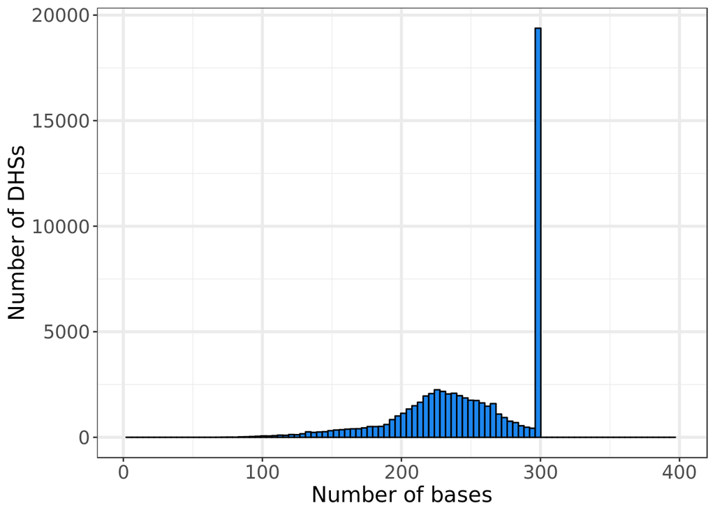

```r
DHSs <- read.table(DHS_file)
size = as.data.frame(DHSs$V3 - DHSs$V2)
colnames(size) = c("bases")
ggplot(size, aes(x=bases)) + geom_histogram(fill="dodgerblue2", col="black", bins = 100) + xlab("Number of bases") + ylab("Number of DHSs") + theme_bw() + theme(panel.grid = element_line(colour = "black", size = 1), axis.text = element_text(size = 13), axis.title = element_text(size = 15)) + xlim(c(1,400))
```

Finally I read another file that can tell me the number of variants that overlap each DHS and I plot the distribution.

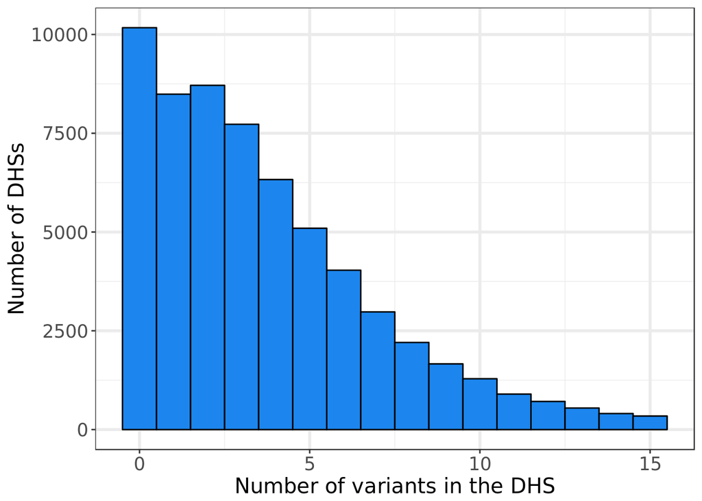

```r
DHSs_variants <- read.table(Num_variants_file)
variants <- as.data.frame(DHSs_variants[,4])
colnames(variants) <- c("number")
variants <- as.data.frame(variants[variants$number<16,])
colnames(variants) <- c("number")
ggplot(variants, aes(x=number)) + geom_histogram(fill="dodgerblue2", col="black", bins = 16) + xlab("Number of variants in the DHS") + ylab("Number of DHSs") + theme_bw() + theme(panel.grid = element_line(colour = "black", size = 1), axis.text = element_text(size = 13), axis.title = element_text(size = 15))
```

Last cool fact about Rmarkdown is that it is possible to run small R codes in line with text to add numbers. For example:  
The median number of variants is : 3